# Saturated Fat Intake and Depression in U.S. Adults

A Cross-Sectional Analysis of NHANES 2021–2023

b.mekuria

2025-12-10

## Overview

- Background & Rationale
- Objectives
- Methods
- Results
- Discussion
- Conclusions

## Background & Rationale

- **Depression**: concerning cause of morbidity globally; prevalence rising in U.S. adults.
  - prevalence count: > 300 million worldwide
  - one of the leading causes of mortality in 15 - 29Y
- **Dietary Factors**: Proposed as modifiers of depression risk; saturated fat implicated in inflammation and neurotransmitter regulation.
- **Gap**: Evidence on saturated fat and depression is mixed; few recent U.S.-based analyses using nationally representative data.

## Methods

- **Design**: Cross-sectional analysis using NHANES 2021–2023. `[demographic, nutritional, depression screener]`
- **Population**: Adults ≥18 years with complete data on saturated fat intake and PHQ-9 depression screening.
- **Variables**:
  - Exposure: Saturated fat intake (grams/day)
  - Covariates: Age, gender, race/ethnicity, education
- **Packages**:
  - haven, ggplot2, mice, table1, DiagrammeR
- **Analysis**:
  - Logistic regression (adjusted)
  - Assumption checks: multicollinearity, goodness-of-fit, linearity
  - Multiple imputation for missing covariates

## Methods

### Outcome Variable: Depression

Moderate-to-severe depression assessed using **PHQ-9** and classified per **DSM-5 criteria**.

1. Binarize **PHQ-9 Questions**: Score ≥ 2 → symptom present.
2. Apply DSM-5 criteria: ≥ 5 symptoms present **AND** at least one core symptom (interest or mood).

PHQ-9 Questions, scored from 0–3 (Not at all - Almost everyday) - Little interest or pleasure in doing things  
- Feeling down, depressed, or hopeless  
- Trouble sleeping or sleeping too much  
- Feeling tired or having little energy  
- Poor appetite or overeating  
- Feeling bad about yourself  
- Trouble concentrating  
- Moving or speaking slowly or being restless  
- Thoughts of self-harm

## Conceptual Model (DAG)

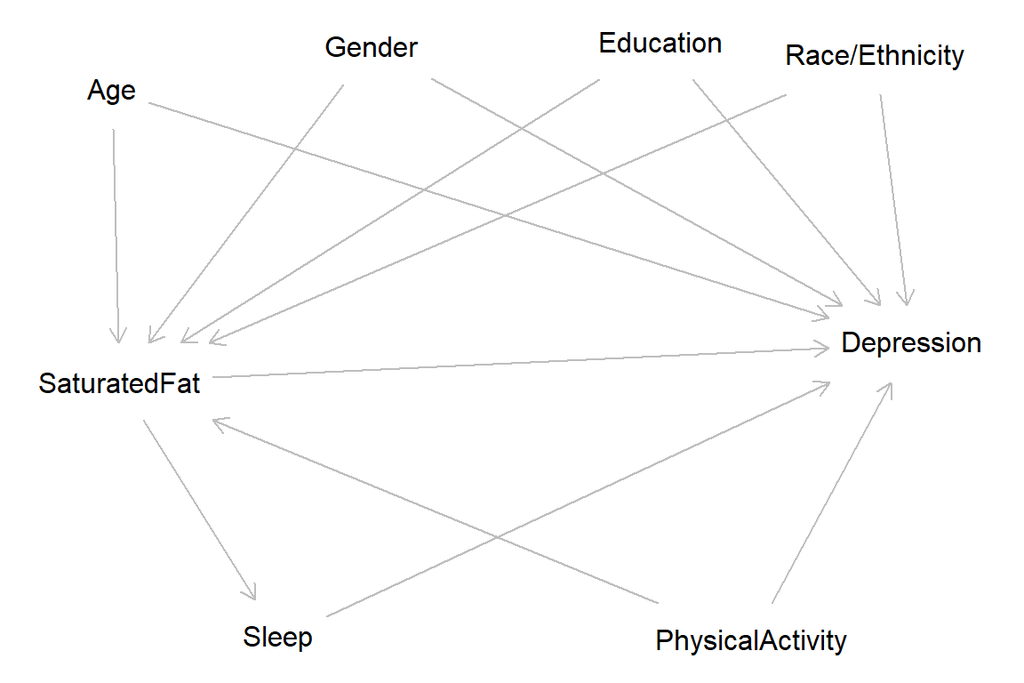

## Methods: Data Processing

[interactive chart not shown]

## Table 1: demographic characteristics of study sample

|  | 0 (N=4755) | 1 (N=231) |
| --- | --- | --- |
| Age (years) |  |  |
| Mean (SD) | 53.9 (17.9) | 48.9 (18.1) |
| Median [Min, Max] | 58.0 [18.0, 80.0] | 52.0 [18.0, 80.0] |
| Gender |  |  |
| Male | 83 (1.7%) | 6 (2.6%) |
| Female | 89 (1.9%) | 9 (3.9%) |
| Missing | 4583 (96.4%) | 216 (93.5%) |
| Ethnicity |  |  |
| Non-Hispanic White | 2927 (61.6%) | 122 (52.8%) |
| Hispanic | 781 (16.4%) | 48 (20.8%) |
| Non-Hispanic Black | 545 (11.5%) | 35 (15.2%) |
| Non-Hispanic Asian | 210 (4.4%) | 4 (1.7%) |
| Other Race | 292 (6.1%) | 22 (9.5%) |
| Education |  |  |
| Less than high school grad | 483 (10.2%) | 46 (19.9%) |
| High school/GED | 915 (19.2%) | 48 (20.8%) |
| Some college/AA | 1374 (28.9%) | 85 (36.8%) |
| College graduate or above | 1810 (38.1%) | 37 (16.0%) |
| Missing | 173 (3.6%) | 15 (6.5%) |
| Saturated Fat Intake (g/day) |  |  |
| Mean (SD) | 26.8 (16.5) | 26.2 (20.2) |
| Median [Min, Max] | 23.7 [0, 154] | 22.4 [0.916, 209] |

## Data Exploration

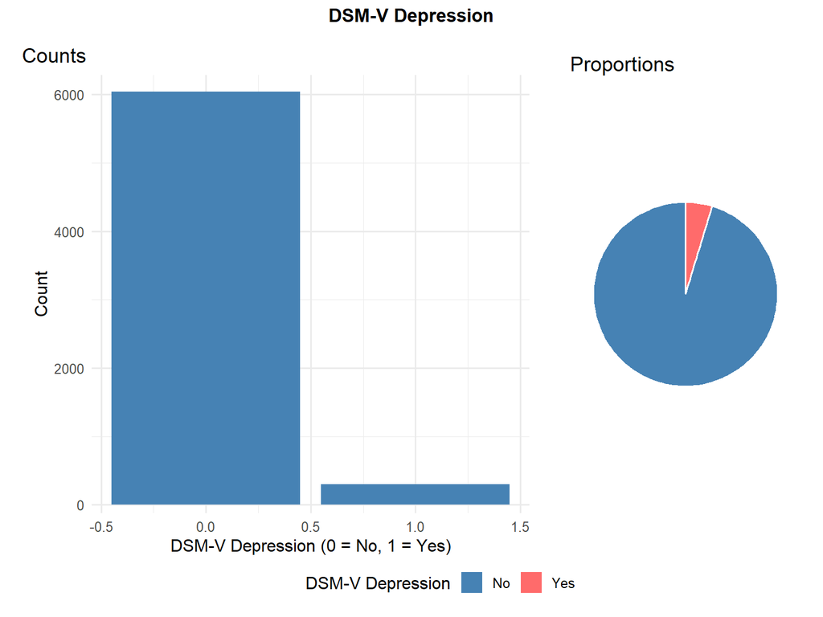

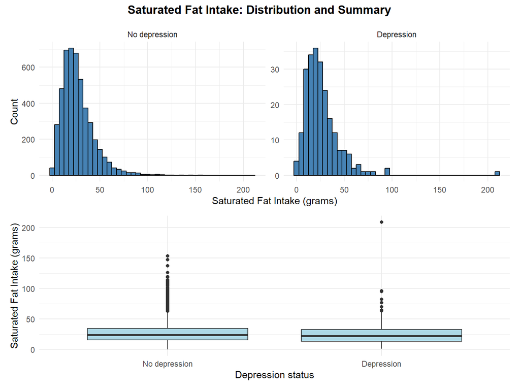

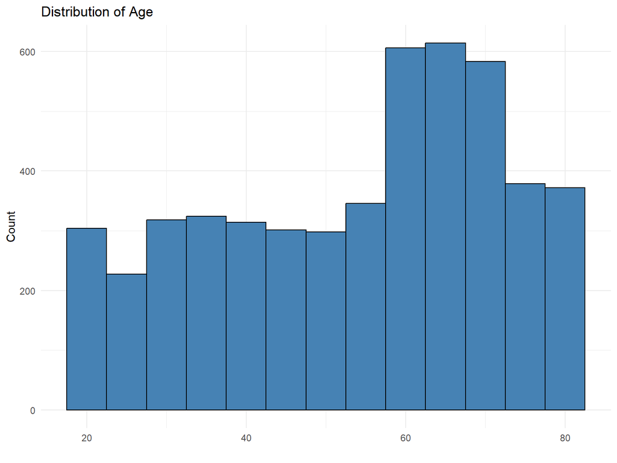

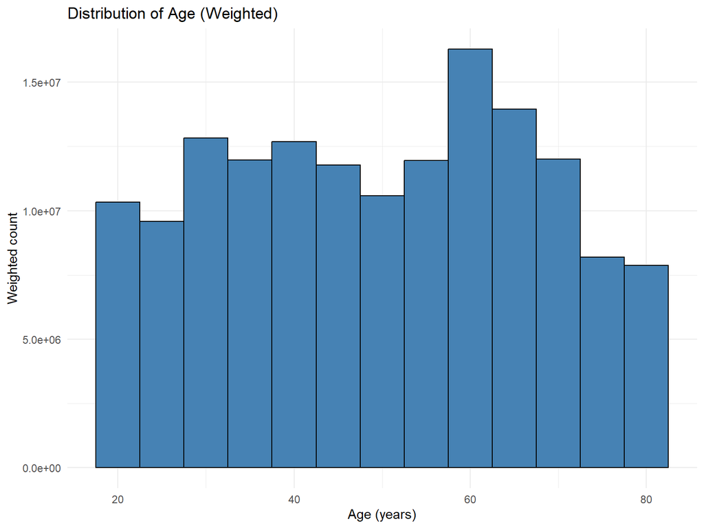

```r
t.test(DR1TSFAT ~ dsmv_depression, data = df_analysis)
```

```
##
##  Welch Two Sample t-test
##
## data:  DR1TSFAT by dsmv_depression
## t = 0.42622, df = 245.22, p-value = 0.6703
## alternative hypothesis: true difference in means between group 0 and group 1 is not equal to 0
## 95 percent confidence interval:
##  -2.081566  3.231180
## sample estimates:
## mean in group 0 mean in group 1
##        26.78660        26.21179
```

```r
# t = 0.42622, df = 245.22, p-value = 0.6703
```

## Missing data

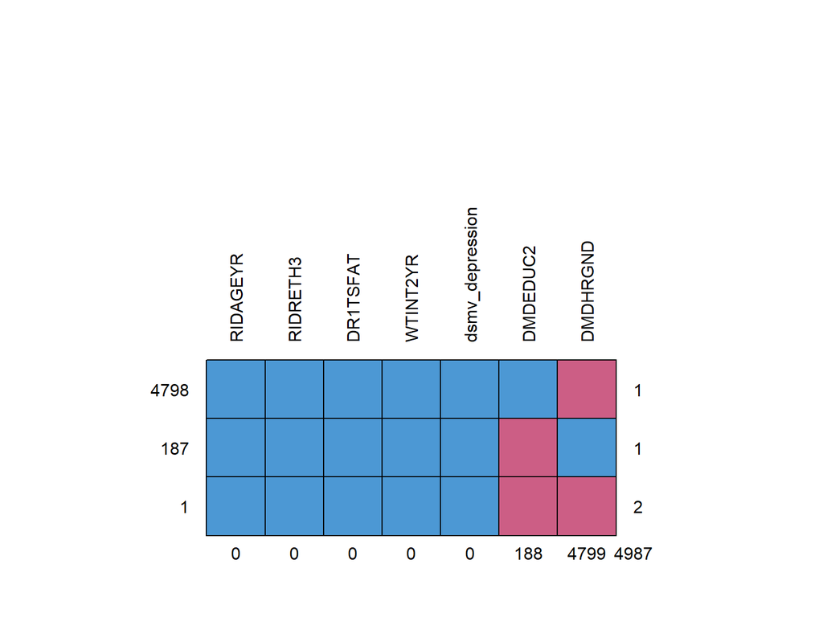

```
##                                 term     estimate   std.error  statistic
## 1                        (Intercept) -1.993336251 0.250633897 -7.9531790
## 2                           DR1TSFAT -0.001727601 0.004019361 -0.4298199
## 3                      RIDAGEYR40-65 -0.220753271 0.158031032 -1.3968982
## 4                        RIDAGEYR>65 -0.748789582 0.187601338 -3.9913872
## 5                   RIDRETH3Hispanic -0.051078228 0.191631669 -0.2665438
## 6         RIDRETH3Non-Hispanic Black  0.110186353 0.203359395  0.5418306
## 7         RIDRETH3Non-Hispanic Asian -0.683793680 0.518407844 -1.3190265
## 8                 RIDRETH3Other Race  0.379666077 0.244313412  1.5540124
## 9            DMDEDUC2High school/GED -0.586337162 0.221203772 -2.6506653
## 10           DMDEDUC2Some college/AA -0.469100709 0.210734012 -2.2260323
## 11 DMDEDUC2College graduate or above -1.434184701 0.235929078 -6.0788806
##           df      p.value
## 1  2603.5543 2.684901e-15
## 2  4965.8615 6.673453e-01
## 3  4964.3198 1.625066e-01
## 4  4961.8369 6.663601e-05
## 5  4586.0206 7.898324e-01
## 6  4867.5989 5.879600e-01
## 7  4969.0831 1.872210e-01
## 8  4884.5231 1.202462e-01
## 9  1285.9493 8.131964e-03
## 10  210.7168 2.707114e-02
## 11 1113.9468 1.659970e-09
```

## Results

pooled results do not show a statistically significant association between saturated fat intake and depression prevalence

[output not shown]

- Age > 65, and being a high-school graduate or higher education were negatively correlated

## Discussion

this analysis did not find a statistically significant association between saturated fat intake and depression among U.S. adults. After adjusting for potential confounders, the effect estimates were close to null, suggesting that saturated fat consumption may not be an independent predictor of depression in this population.

## Discussion

### Strengths

Use of a large, nationally representative dataset; standardized measures of depression; adjustment for multiple confounders.

### Limitations

- self reported
- retrospective
- cross sectional
- non-generalizable distribution

## Acknowlagements

- Dr. Kim Johnson
- Cindy Kang
- The internet